# Lecture 14: Unsupervised Learning

November, 2015

## Today

- new later exam date
- KNN
- Classification and Regression Tree (CART)
- unsupervised learning

## Classification

When we are trying to predict discrete outcomes we are effictively doing classification

We saw last time that the logit model could be used for predictions

Today I want to show you an alternative approach: KNN

## K Nearest Neighbors

KNN attempts to estimate the conditional distribution of \(Y\) given \(X\), and then classify a given observation to the class with the highest estimated probability.

Specifically, given a positive integer \(K\) and a test observation \(x_0\), KNN identifies the \(K\) points in the training data that are closest to \(x_0\), represented by \(N_0\).

It then estimates the conditional probability for class \(j\) as the fraction of points in \(N_0\) whose response values equal \(j\):

\[Pr(Y = j|X = x_0) = \frac{1}{K} \sum_{i \in N_0} I(y_i = j)\]

and predicts based on majority vote

**Question:** What is the prediction when K = N?

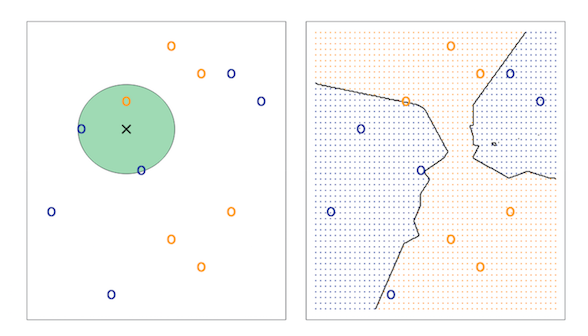

## Choosing k

The choice of \(k\) or the number of neighbors to be included in the classification at a new point is important.

A common choice is to take \(k = 1\) but this can give rise to very irregular and jagged regions with high variances in prediction.

Larger choices of \(k\) lead to smoother regions and less variable classifications, but do not capture local details and can have larger biases.

Cross-validate!

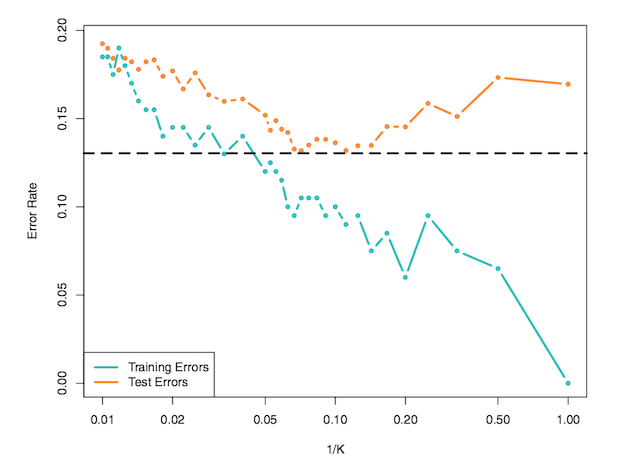

## Curse of dimensionality

Distance is often Euclidean distance

kNN breaks down in high-dimensional space

This is because the "neighborhood" becomes very large

This is often called the curse of dimensionality.

## Classification and Regression Trees (CART)

Decision trees can be applied to both regression and classification problems

They are intuitive, but run the danger of overfitting (what happens if you grow the largest possible decision tree for a given problem?)

Therefore, people usually use extensions such as random forests

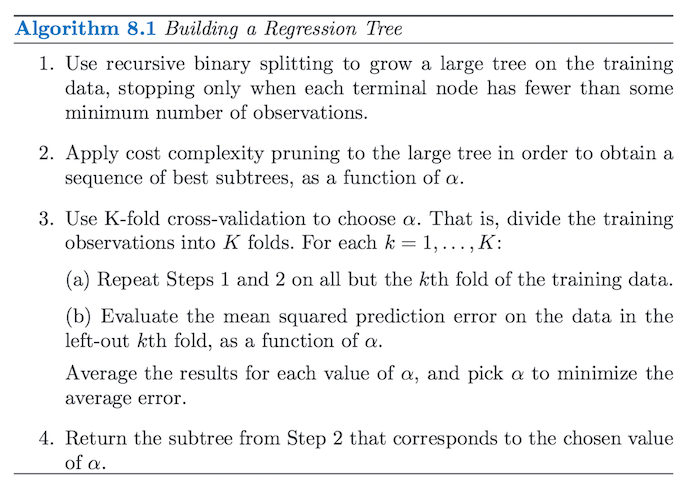

## Advantages of tree based methods

Easy to explain

Mimics the mental model we often use to make decisions

Can easily be displayed graphically

Main disadvantage:

Performance

## CART example: Classifying cuisine given ingredients

```r
library("jsonlite")
food = fromJSON("~/git/sds/data/food.json")
head(food)
```

```
##      id     cuisine
## 1 10259       greek
## 2 25693 southern_us
## 3 20130    filipino
## 4 22213      indian
## 5 13162      indian
## 6  6602    jamaican
##                                                                                                                                                                                                                                        ingredients
## 1                                                                                                                     romaine lettuce, black olives, grape tomatoes, garlic, pepper, purple onion, seasoning, garbanzo beans, feta cheese crumbles
## 2                                                                                                              plain flour, ground pepper, salt, tomatoes, ground black pepper, thyme, eggs, green tomatoes, yellow corn meal, milk, vegetable oil
## 3                                                                                               eggs, pepper, salt, mayonaise, cooking oil, green chilies, grilled chicken breasts, garlic powder, yellow onion, soy sauce, butter, chicken livers
## 4                                                                                                                                                                                                                water, vegetable oil, wheat, salt
## 5 black pepper, shallots, cornflour, cayenne pepper, onions, garlic paste, milk, butter, salt, lemon juice, water, chili powder, passata, oil, ground cumin, boneless chicken skinless thigh, garam masala, double cream, natural yogurt, bay leaf
## 6                                                                                                  plain flour, sugar, butter, eggs, fresh ginger root, salt, ground cinnamon, milk, vanilla extract, ground ginger, powdered sugar, baking powder
```

## Good thing we had Zoltan here last week…

```r
library("tm")
combi_ingredients = c(Corpus(VectorSource(food$ingredients)), Corpus(VectorSource(food$ingredients)))
combi_ingredients = tm_map(combi_ingredients, stemDocument, language="english")
combi_ingredientsDTM = DocumentTermMatrix(combi_ingredients)
combi_ingredientsDTM = removeSparseTerms(combi_ingredientsDTM, 0.99)
combi_ingredientsDTM = as.data.frame(as.matrix(combi_ingredientsDTM))
combi = combi_ingredientsDTM
combi_ingredientsDTM$cuisine = as.factor(c(food$cuisine, rep("italian", nrow(food))))
```

## Our food data

```r
names(combi_ingredientsDTM)[1:15]
```

```
##  [1] "all_purpos" "allspic"    "almond"     "and"        "appl"
##  [6] "avocado"    "babi"       "bacon"      "bake"       "balsam"
## [11] "basil"      "bay"        "bean"       "beansprout" "beef"
```

```r
trainDTM  = combi_ingredientsDTM[1:nrow(food), ]
testDTM = combi_ingredientsDTM[-(1:nrow(food)), ]
```

## Estimate the model

```r
library("rpart")
set.seed(1)
model = rpart(cuisine ~ ., data = trainDTM, method = "class")
cuisine = predict(model, newdata = testDTM, type = "class")
summary(model)
```

```
## Call:
## rpart(formula = cuisine ~ ., data = trainDTM, method = "class")
##   n= 39774
##
##           CP nsplit rel error    xerror        xstd
## 1 0.07781187      0 1.0000000 1.0000000 0.002484064
## 2 0.03143788      1 0.9221881 0.9221881 0.002737618
## 3 0.01000000      6 0.7362224 0.7310559 0.003074783
##
## Variable importance
##     tortilla     parmesan          soy       masala        garam
##           19           13           12            8            7
##         oliv     cilantro        grate        sesam          oil
##            7            7            4            4            3
##         sauc        chees extra_virgin         chip         jack
##            2            2            2            2            2
##        salsa     monterey        mirin       chines         wine
##            2            1            1            1            1
##      parsley
##            1
##
## Node number 1: 39774 observations,    complexity param=0.07781187
##   predicted class=italian      expected loss=0.8029366  P(node) =1
##     class counts:   467   804  1546  2673   755  2646  1175  3003   667  7838   526  1423   830  6438   821   489  4320   989  1539   825
##    probabilities: 0.012 0.020 0.039 0.067 0.019 0.067 0.030 0.076 0.017 0.197 0.013 0.036 0.021 0.162 0.021 0.012 0.109 0.025 0.039 0.021
##   left son=2 (37167 obs) right son=3 (2607 obs)
##   Primary splits:
##       tortilla < 0.5 to the left,  improve=1966.590, (0 missing)
##       parmesan < 0.5 to the right, improve=1398.459, (0 missing)
##       soy      < 0.5 to the right, improve=1331.248, (0 missing)
##       chees    < 0.5 to the left,  improve=1126.163, (0 missing)
##       cilantro < 0.5 to the left,  improve=1096.958, (0 missing)
##   Surrogate splits:
##       chip     < 0.5 to the left,  agree=0.940, adj=0.092, (0 split)
##       jack     < 0.5 to the left,  agree=0.940, adj=0.087, (0 split)
##       salsa    < 0.5 to the left,  agree=0.940, adj=0.085, (0 split)
##       monterey < 0.5 to the left,  agree=0.938, adj=0.059, (0 split)
##       jalapeno < 1.5 to the left,  agree=0.935, adj=0.002, (0 split)
##
## Node number 2: 37167 observations,    complexity param=0.03143788
```

[output cut: 106 more lines]

```
##
## Node number 47: 3515 observations
##   predicted class=mexican      expected loss=0.569559  P(node) =0.08837431
##     class counts:    79     4    22    52     8    13     9   603     4    39    25    28     5  1513   275     8    51    77   470   230
##    probabilities: 0.022 0.001 0.006 0.015 0.002 0.004 0.003 0.172 0.001 0.011 0.007 0.008 0.001 0.430 0.078 0.002 0.015 0.022 0.134 0.065
##
## Node number 92: 7367 observations
##   predicted class=italian      expected loss=0.5743179  P(node) =0.1852215
##     class counts:    85    69   348    27    34   738   729   182    57  3136    43    29    14   509   316    58   359   588    32    14
##    probabilities: 0.012 0.009 0.047 0.004 0.005 0.100 0.099 0.025 0.008 0.426 0.006 0.004 0.002 0.069 0.043 0.008 0.049 0.080 0.004 0.002
##
## Node number 93: 17828 observations
##   predicted class=southern_us  expected loss=0.7908346  P(node) =0.4482325
##     class counts:   275   713  1100   550   422  1775   377  1238   591  2206   370   553   273  1840   217   416  3729   301   534   348
##    probabilities: 0.015 0.040 0.062 0.031 0.024 0.100 0.021 0.069 0.033 0.124 0.021 0.031 0.015 0.103 0.012 0.023 0.209 0.017 0.030 0.020
```

## Does the tree pass the smell test?

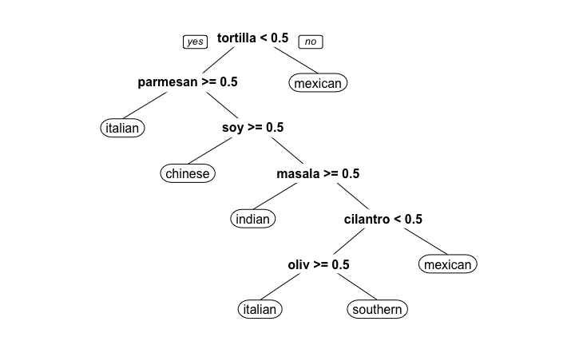

```r
library("rpart.plot")
prp(model)
```

## Random forests

Random Forest algoriths are so-called ensemble models

This means that the model consists of many smaller models

The sub-models for Random Forests are classification and regression trees

## Bagging

Breiman (1996) proposed bootstrap aggregating – “bagging” – to to reduce the risk of overfitting.

The core idea of bagging is to decrease the variance of the predictions of one model, by fitting several models and averaging over their predictions

In order to obtain a variety of models that are not overfit to the available data, each component model is fit only to a bootstrap sample of the data

## Random forest intution

Random forests extended the logic of bagging to predictors.

This means that, instead of choosing the split from among all the explanatory variables at each node in each tree, only a random subset of the explanatory variables are used

If there are some very important variables they might overshadow the effect of weaker predictors because the algorithm searches for the split that results in the largest reduction in the loss function.

If at each split only a subset of predictors are available to be chosen, weaker predictors get a chance to be selected more often, reducing the risk of overlooking such variables

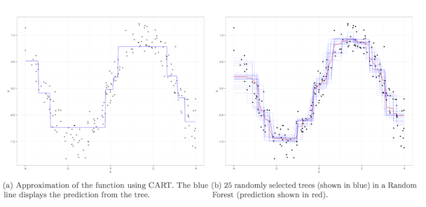

Jones & Linder. 2015. [Exploratory Data Analysis using Random Forests](http://zmjones.com/static/papers/rfss_manuscript.pdf).

## Unsupervised Learning

## Supervised vs unsupervised

**Supervised**

- You have an outcome Y and some covariates X

**Unsupervised**

- You have a bunch of observations X and you want to understand the relationships between them.
- You are usually trying to understand patterns in X or group the variables in X in some way

## Examples of unsupervised learning

Principal Components Analysis

Clustering

## Principal Components Analysis

You have a set of multivariate variables \(X_1,...,X_p\)

- Find a new set of multivariate variables that are uncorrelated and explain as much variance as possible.
- If you put all the variables together in one matrix, find the best matrix created with fewer variables (lower rank) that explains the original data.

The first goal is statistical and the second goal is data compression.

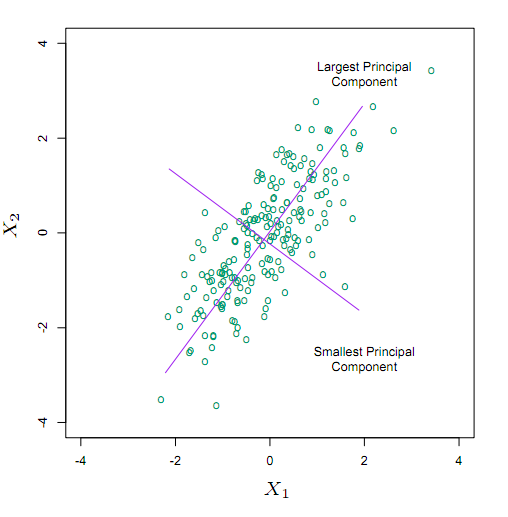

## Example: Building a market index

```r
library("readr")

df = read_csv("https://raw.githubusercontent.com/johnmyleswhite/ML_for_Hackers/master/08-PCA/data/stock_prices.csv")
head(df)
```

```
##         Date Stock Close
## 1 2011-05-25   DTE 51.12
## 2 2011-05-24   DTE 51.51
## 3 2011-05-23   DTE 51.47
## 4 2011-05-20   DTE 51.90
## 5 2011-05-19   DTE 51.91
## 6 2011-05-18   DTE 51.68
```

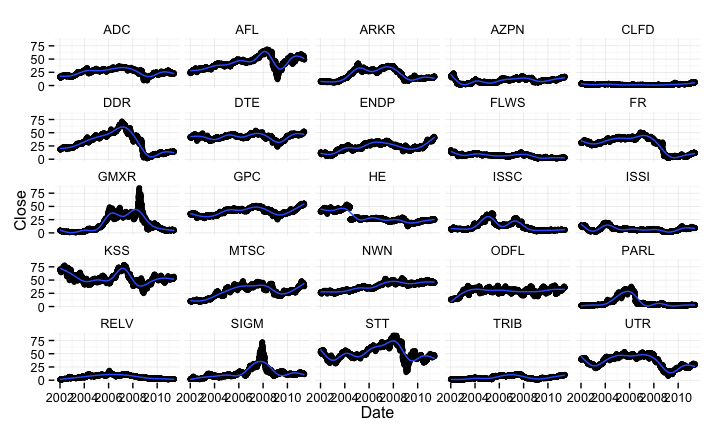

## Market index

Idea: Let's reduce the 25 stocks to 1 dimension and let's call that our *market index*

Dimensionality reduction: shrink a large number of correlated variables into a smaller number

Can be used in many different situations: when we have too many variables for OLS, for unsupervised learning, etc.

```r
library("tidyr")
df.wide = df %>% spread(Stock, Close)
df.wide = df.wide[complete.cases(df.wide), ]
head(df.wide)
```

```
## Source: local data frame [6 x 26]
##
##         Date   ADC   AFL  ARKR  AZPN  CLFD   DDR   DTE  ENDP  FLWS    FR
##       (date) (dbl) (dbl) (dbl) (dbl) (dbl) (dbl) (dbl) (dbl) (dbl) (dbl)
## 1 2002-01-02 17.70 23.78  8.15 17.10  3.19 18.80 42.37 11.54 15.77 31.16
## 2 2002-01-03 16.14 23.52  8.15 17.41  3.27 18.55 42.14 11.48 17.40 31.45
## 3 2002-01-04 15.45 23.92  7.79 17.90  3.28 18.46 41.79 11.60 17.11 31.46
## 4 2002-01-07 16.59 23.12  7.79 17.49  3.50 18.30 41.48 11.90 17.38 31.10
## 5 2002-01-08 16.76 25.54  7.35 17.89  4.24 18.57 40.69 12.41 14.62 31.40
## 6 2002-01-09 16.78 26.30  7.40 18.25  4.25 18.41 40.81 12.27 14.27 31.05
## Variables not shown: GMXR (dbl), GPC (dbl), HE (dbl), ISSC (dbl), ISSI
##   (dbl), KSS (dbl), MTSC (dbl), NWN (dbl), ODFL (dbl), PARL (dbl), RELV
##   (dbl), SIGM (dbl), STT (dbl), TRIB (dbl), UTR (dbl)
```

## PCA

```r
library("dplyr")
pca = princomp(select(df.wide, -Date))
summary(pca)
```

```
## Importance of components:
##                            Comp.1     Comp.2      Comp.3      Comp.4
## Standard deviation     32.8783239 21.9458151 12.66604184 11.48519188
## Proportion of Variance  0.5023324  0.2238078  0.07455103  0.06129829
## Cumulative Proportion   0.5023324  0.7261402  0.80069122  0.86198951
##                            Comp.5     Comp.6     Comp.7     Comp.8
## Standard deviation     8.52597847 8.21798001 6.15711399 5.14393138
## Proportion of Variance 0.03378005 0.03138354 0.01761677 0.01229595
## Cumulative Proportion  0.89576956 0.92715310 0.94476987 0.95706582
##                            Comp.9    Comp.10     Comp.11     Comp.12
## Standard deviation     4.79763615 4.29050691 3.516427432 2.659538627
## Proportion of Variance 0.01069612 0.00855439 0.005746126 0.003286884
## Cumulative Proportion  0.96776195 0.97631634 0.982062463 0.985349347
##                            Comp.13     Comp.14     Comp.15    Comp.16
## Standard deviation     2.530919035 2.177211855 2.040659474 1.88598714
## Proportion of Variance 0.002976654 0.002202791 0.001935142 0.00165291
## Cumulative Proportion  0.988326001 0.990528791 0.992463934 0.99411684
##                            Comp.17     Comp.18      Comp.19      Comp.20
## Standard deviation     1.725447133 1.638980130 1.4166499216 1.1858865221
## Proportion of Variance 0.001383487 0.001248301 0.0009326032 0.0006535188
## Cumulative Proportion  0.995500331 0.996748632 0.9976812350 0.9983347538
##                             Comp.21      Comp.22      Comp.23      Comp.24
## Standard deviation     1.1219624494 0.9370250272 0.8490574411 0.7360680459
## Proportion of Variance 0.0005849631 0.0004080132 0.0003350009 0.0002517722
## Cumulative Proportion  0.9989197169 0.9993277301 0.9996627310 0.9999145032
##                             Comp.25
## Standard deviation     4.289326e-01
## Proportion of Variance 8.549683e-05
## Cumulative Proportion  1.000000e+00
```

## Creating market index

```r
market.index = predict(pca)[, 1]
market.index = data.frame(market.index = market.index, Date = df.wide$Date)
```

**Question**: How do we validate our index?

One suggestion: we can compare it to Dow Jones

```r
library("lubridate")
dj = read_csv("https://raw.githubusercontent.com/johnmyleswhite/ML_for_Hackers/master/08-PCA/data/DJI.csv")
dj = dj %>% filter(ymd(Date) > ymd('2001-12-31')) %>%
  filter(ymd(Date) != ymd('2002-02-01')) %>% select(Date, Close)
market.data = inner_join(market.index, dj)
head(market.data)
```

```
##   market.index       Date    Close
## 1     28.24125 2002-01-02 10073.40
## 2     28.16625 2002-01-03 10172.14
## 3     28.07273 2002-01-04 10259.74
## 4     28.30203 2002-01-07 10197.05
## 5     27.62799 2002-01-08 10150.55
## 6     27.49861 2002-01-09 10094.09
```

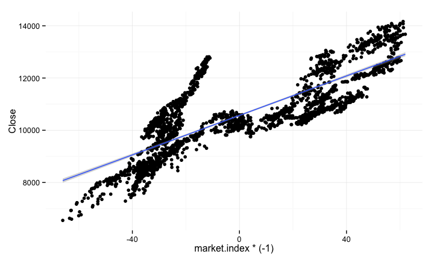

```r
market.data = market.data %>%
  mutate(
    market.index = scale(market.index * (-1)),
    Close = scale(Close)
  )
market.data = market.data %>% gather(index, value, -Date)
head(market.data)
```

```
##         Date        index      value
## 1 2002-01-02 market.index -0.8587810
## 2 2002-01-03 market.index -0.8565003
## 3 2002-01-04 market.index -0.8536565
## 4 2002-01-07 market.index -0.8606292
## 5 2002-01-08 market.index -0.8401325
## 6 2002-01-09 market.index -0.8361982
```

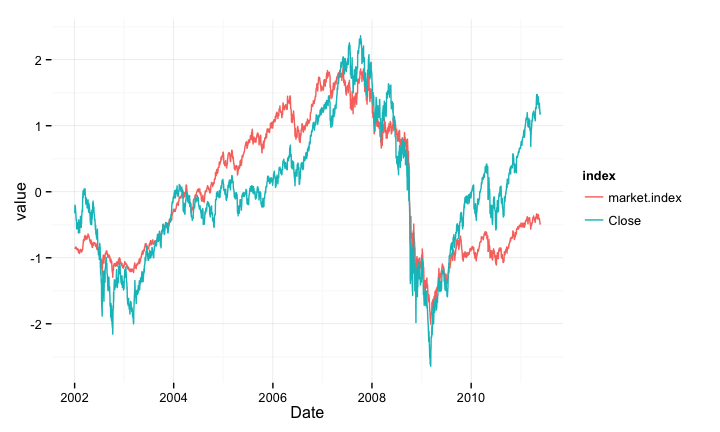

## Clustering

An alternative approach to unsupervised learning is clustering

In the following we will use MDS - Multidirectional Scaling - to study polarization of politicians in the U.S Congress

## MDS

MDS is a set of statistical techniques used to visually depict the similarities and differences from a set of distances

The model takes a distance matrix that specifies the (usually Euclidean) distance between every pair of points in our data and returns a set of coordinates for those two points that approximates those distances

It is implemented in base R in the `cmdscale` function

## Ideology in the U.S Congress

```r
data.dir = "~/git/sds/data"
files = list.files(data.dir, pattern =".dta")

library("foreign")
rollcall.data = lapply(files,
    function(f){read.dta(file.path(data.dir, f), convert.factors = FALSE)})
```

## Cleaning…

```r
rollcall.simplified = function(df){
  no.pres = subset(df, state < 99)
  for(i in 10:ncol(no.pres)){
    no.pres[,i] = ifelse(no.pres[,i] > 6, 0, no.pres[,i])
    no.pres[,i] = ifelse(no.pres[,i] > 0 & no.pres[,i] < 4, 1, no.pres[,i])
    no.pres[,i] = ifelse(no.pres[,i] > 1, -1, no.pres[,i])
  }
  return(as.matrix(no.pres[,10:ncol(no.pres)]))
}

rollcall.simple = lapply(rollcall.data, rollcall.simplified)
```

```r
dim(rollcall.simple[[1]])
```

```
## [1] 102 638
```

```r
head(rollcall.simple[[1]])
```

```
##   V1 V2 V3 V4 V5 V6 V7 V8 V9 V10 V11 V12 V13 V14 V15 V16 V17 V18 V19 V20
## 2  1  1  1  1  1  1  1  1  1   1   1   1   1   1   1   1   1   1   1  -1
## 3  1  1  1  1  1  1  1  1  1   1   1   1   1  -1  -1   1   1   1   1   1
## 4  1  1  1  1  1  1  1  1  1   1  -1  -1   1   1   1   1   1   1   1   1
## 5  1  1  1  1  1  1  1  1  1   1  -1  -1   1   1  -1   1   1   1   1   1
## 6  1  1  1  1  1  1  1  1  1   1   1   1   1   1   1   1   1   1   1  -1
## 7  1  1  1  1  1  1  1  1  1   1   1   1   1  -1  -1   1   1   1   1   1
##   V21 V22 V23 V24 V25 V26 V27 V28 V29 V30 V31 V32 V33 V34 V35 V36 V37 V38
## 2   1  -1  -1   1   1   1  -1   1   1  -1   1   1   1   1   1   1   1  -1
## 3   1  -1  -1   1   1   1  -1   1   1  -1   1   1   1   1   1   1   1  -1
## 4   1  -1  -1   1   1   1   1   1  -1   1   1   1   1   1   1   1   1   1
## 5   1  -1  -1   1   1   1   1   1  -1   1   1   1   1   1   1   1  -1   1
## 6   1  -1  -1   1   1   1   1   1   1  -1   1   1   1   1   1   1   1  -1
## 7   1  -1  -1   1   1   1   1   1  -1   1   1   1   1   1   1  -1  -1   1
##   V39 V40 V41 V42 V43 V44 V45 V46 V47 V48 V49 V50 V51 V52 V53 V54 V55 V56
```

[output cut: 293 more lines]

```r
rollcall.dist = lapply(rollcall.simple, function(x) dist(x %*% t(x)))
rollcall.mds = lapply(rollcall.dist,
                       function(d) as.data.frame((cmdscale(d, k = 2)) * -1))

congresses = 101:111

for(i in 1:length(rollcall.mds))
{
  names(rollcall.mds[[i]]) = c("x", "y")

  congress = subset(rollcall.data[[i]], state < 99)

  congress.names = sapply(as.character(congress$name),
                           function(n) strsplit(n, "[, ]")[[1]][1])

  rollcall.mds[[i]] = transform(rollcall.mds[[i]],
                                 name = congress.names,
                                 party = as.factor(congress$party),
                                 congress = congresses[i])
}

head(rollcall.mds[[1]])
```

```
##            x        y      name party congress
## 2  -11.44068 293.0001    SHELBY   100      101
## 3  283.82580 132.4369    HEFLIN   100      101
## 4  885.85564 430.3451   STEVENS   200      101
## 5 1714.21327 185.5262 MURKOWSKI   200      101
## 6 -843.58421 220.1038 DECONCINI   100      101
## 7 1594.50998 225.8166    MCCAIN   200      101
```

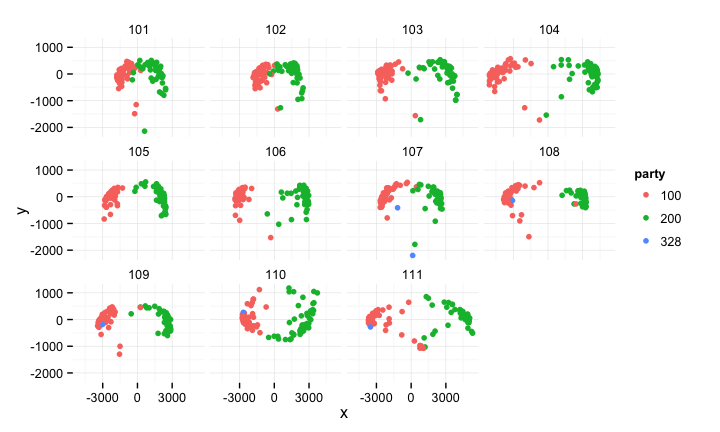